# A Política Econômica promove a fruição da saúde e da igualdade econômica?

01/12/2020

## A efetividade de direitos sociais

A política econômica, representada pelo tripé macroeconômico – na figura das variáveis **superávit primário (SP)** e **juros (J)**, deveria ter como um dos seus objetivos centrais a promoção da efetividade da fruição de direitos subjetivos dos cidadãos, por exemplo de dois direitos subjetivos fundamentais a ela subjacente: à saúde e à igualdade.

A escolha desses direitos é decorrente, de um lado, da decomposição analítica da fruição (disponibilidade de dados); e, de outro, da importância da saúde e da igualdade econômica para o desenvolvimento econômico e social de uma sociedade que se pretende ser desenvolvida.

## Decomposição analítica do direito à saúde e à igualdade econômica

Adota-se quatro indicadores representativos desses direitos no período de 2002 a 2019. No caso do direito à saúde, escolheu-se a **expectativa de vida ao nascer - EVN** e a **taxa de mortalidade infantil (por mil nascidos vivos) - TMI**. Em relação ao direito à igualdade, optou-se pela **taxa de pobreza (TP)** e o **índice de gini (IG)**.

## Relação da política econômica com o direito à saúde e à igualdade econômica

Entende-se razoável, do ponto de vista da economia ortodoxa, que o crescimento do PIB (correlacionado com uma política fiscal sustentável: existência de superávit primário; e como uma política monetária frouxa: juros baixos) teria que resultar na melhoria desses indicadores sociais que afetam a população de um país como um todo.

## Indicador da efetividade da política econômica (IFE)

Um possível indicador empírico da efetividade da política econômica (IFE) pode ser dada pela seguinte equação:

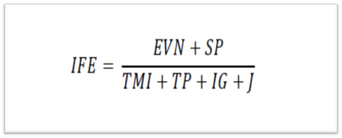

## Descrição do Banco de Dados 1

```
## Rows: 18
## Columns: 10
## $ ANO      <chr> "2002", "2003", "2004", "2005", "2006", "2007", "2008", "2...
## $ CAMB     <dbl> 2.9309, 3.0715, 2.9257, 2.4341, 2.1771, 1.9483, 1.8375, 1....
## $ JUROS    <dbl> 19.173057, 23.345449, 16.246292, 19.049810, 15.076799, 11....
## $ POBR     <dbl> 34.38, 35.75, 33.71, 30.83, 26.75, 25.36, 22.60, 21.41, 19...
## $ GINI     <dbl> 0.5892865, 0.5830195, 0.5724592, 0.5695264, 0.5629743, 0.5...
## $ EXP_VIDA <dbl> 70.72699, 71.15839, 71.57998, 71.98938, 72.38750, 72.77262...
## $ MORT_INF <dbl> 26.04, 24.68, 23.39, 22.18, 21.04, 19.98, 18.99, 18.07, 17...
## $ PIB      <dbl> 1.0305346, 1.0114000, 1.0576000, 1.0320000, 1.0396199, 1.0...
## $ IPCA     <dbl> 1.125303, 1.093005, 1.075995, 1.056892, 1.031415, 1.044577...
## $ SUP_PRIM <dbl> 3.19, 3.24, 3.69, 3.74, 3.15, 3.24, 3.33, 1.94, 2.62, 2.94...
```

## Descrição do Banco de Dados 2

```
## # A tibble: 5 x 10
##   ANO    CAMB JUROS  POBR  GINI EXP_VIDA MORT_INF   PIB  IPCA SUP_PRIM
##   <chr> <dbl> <dbl> <dbl> <dbl>    <dbl>    <dbl> <dbl> <dbl>    <dbl>
## 1 2002   2.93  19.2  34.4 0.589     70.7     26.0  1.03  1.13     3.19
## 2 2003   3.07  23.3  35.8 0.583     71.2     24.7  1.01  1.09     3.24
## 3 2004   2.93  16.2  33.7 0.572     71.6     23.4  1.06  1.08     3.69
## 4 2005   2.43  19.0  30.8 0.570     72.0     22.2  1.03  1.06     3.74
## 5 2006   2.18  15.1  26.8 0.563     72.4     21.0  1.04  1.03     3.15
```

## Descrição do Banco de Dados 3

| ANO | CAMB | JUROS | POBR | GINI | EXP_VIDA | MORT_INF | PIB | IPCA | SUP_PRIM |
| --- | --- | --- | --- | --- | --- | --- | --- | --- | --- |
| 2002 | 2.93 | 19.17 | 34.38 | 0.59 | 70.73 | 26.04 | 1.03 | 1.13 | 3.19 |
| 2003 | 3.07 | 23.35 | 35.75 | 0.58 | 71.16 | 24.68 | 1.01 | 1.09 | 3.24 |
| 2004 | 2.93 | 16.25 | 33.71 | 0.57 | 71.58 | 23.39 | 1.06 | 1.08 | 3.69 |
| 2005 | 2.43 | 19.05 | 30.83 | 0.57 | 71.99 | 22.18 | 1.03 | 1.06 | 3.74 |
| 2006 | 2.18 | 15.08 | 26.75 | 0.56 | 72.39 | 21.04 | 1.04 | 1.03 | 3.15 |
| 2007 | 1.95 | 11.88 | 25.36 | 0.56 | 72.77 | 19.98 | 1.06 | 1.04 | 3.24 |

## Cálculo do Alfa de Cronbach

```
## Some items ( EXP_VIDA ) were negatively correlated with the total scale and
## probably should be reversed.
## To do this, run the function again with the 'check.keys=TRUE' option
```

```
##
## Reliability analysis
##  raw_alpha std.alpha G6(smc) average_r S/N   ase mean sd median_r
##       0.67       0.7    0.98      0.23 2.4 0.019   17  2      0.4
```

## Correlação entre as variáveis

```
##          CAMB JUROS POBR GINI EXP_VIDA MORT_INF IPCA SUP_PRIM
## CAMB      1.0   0.7  0.4  0.4     -0.3      0.4  0.8     -0.3
## JUROS     0.7   1.0  0.9  0.9     -0.8      0.8  0.5      0.4
## POBR      0.4   0.9  1.0  1.0     -1.0      1.0  0.3      0.7
## GINI      0.4   0.9  1.0  1.0     -1.0      1.0  0.3      0.7
## EXP_VIDA -0.3  -0.8 -1.0 -1.0      1.0     -1.0 -0.2     -0.8
## MORT_INF  0.4   0.8  1.0  1.0     -1.0      1.0  0.3      0.7
## IPCA      0.8   0.5  0.3  0.3     -0.2      0.3  1.0     -0.2
## SUP_PRIM -0.3   0.4  0.7  0.7     -0.8      0.7 -0.2      1.0
```

## Correlograma

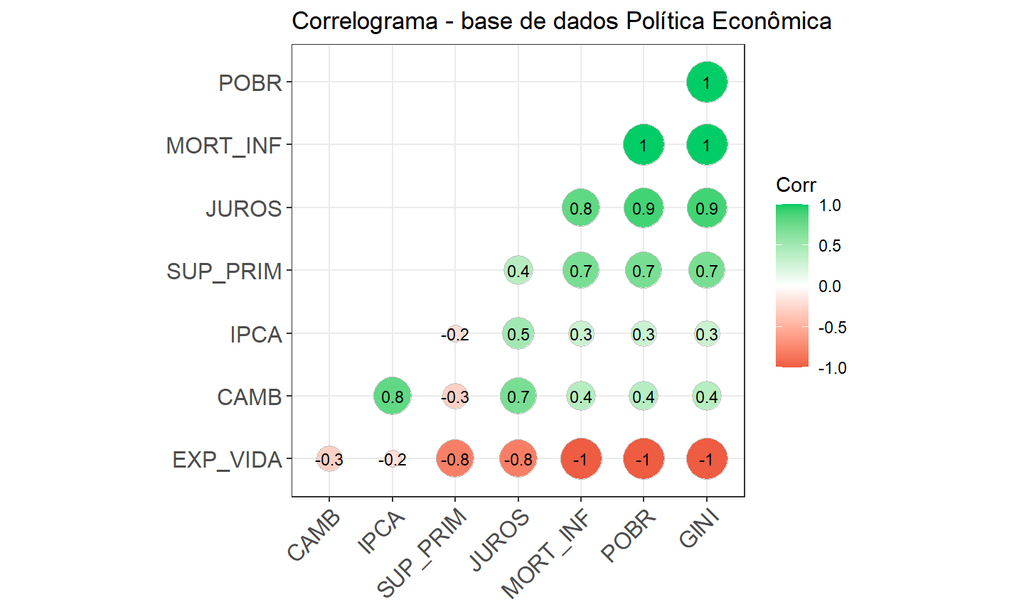

## Cálculo da IFEx100

```
## # A tibble: 14 x 8
##    ANO   EXP_VIDA SUP_PRIM MORT_INF  POBR  GINI JUROS   IFE
##    <chr>    <dbl>    <dbl>    <dbl> <dbl> <dbl> <dbl> <dbl>
##  1 2002      70.7     3.19     26.0  34.4 0.589 19.2   92.2
##  2 2003      71.2     3.24     24.7  35.8 0.583 23.3   88.2
##  3 2004      71.6     3.69     23.4  33.7 0.572 16.2  102.
##  4 2005      72.0     3.74     22.2  30.8 0.570 19.0  104.
##  5 2006      72.4     3.15     21.0  26.8 0.563 15.1  119.
##  6 2007      72.8     3.24     20.0  25.4 0.556 11.9  132.
##  7 2008      73.1     3.33     19.0  22.6 0.546 12.5  140.
##  8 2009      73.5     1.94     18.1  21.4 0.543  9.93 151.
##  9 2010      73.9     2.62     17.2  19.9 0.537  9.76 161.
## 10 2011      74.2     2.94     16.4  18.4 0.531 11.6  164.
## 11 2012      74.5     2.18     15.7  15.9 0.530  8.49 189.
## 12 2013      74.8     1.51     15.0  15.1 0.527  8.22 196.
## 13 2014      75.1    -0.56     14.4  13.3 0.518 10.9  191.
## 14 2015      75.4    -1.86     13.8  14.4 0.525 13.3  175.
```

## Evolução da IFE no período 2002-2015

O gráfico mostra que a efetividade da política econômica (IFE) alcança o valor máximo em 2013 e começa a declinar em 2014, quando o superávit primário torna-se negativo.

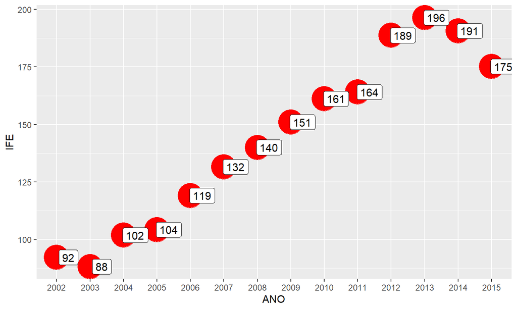

## Gráfico do IFE por ano e superávit primário

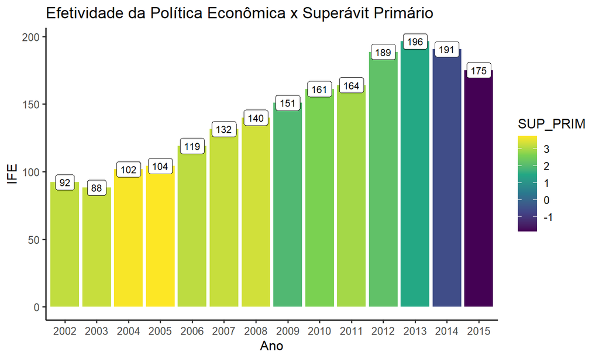

## Gráfico do IFE por ano e expectativa de vida

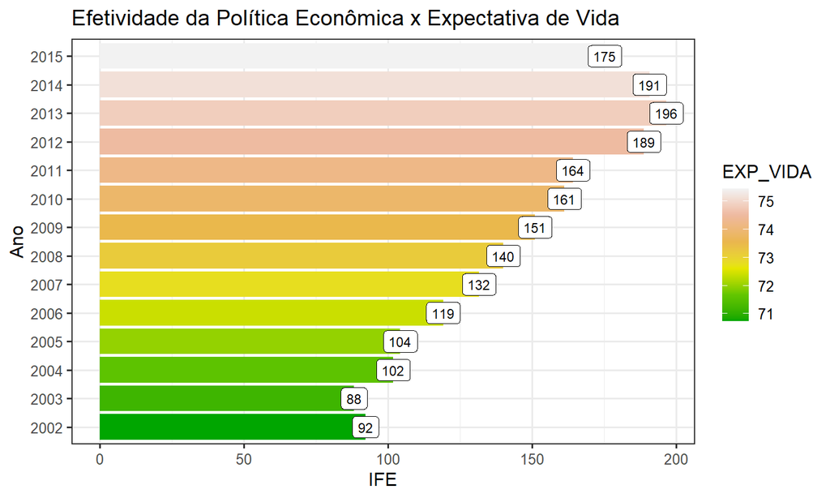

## Gráfico do IFE por ano e mortalidade infantil

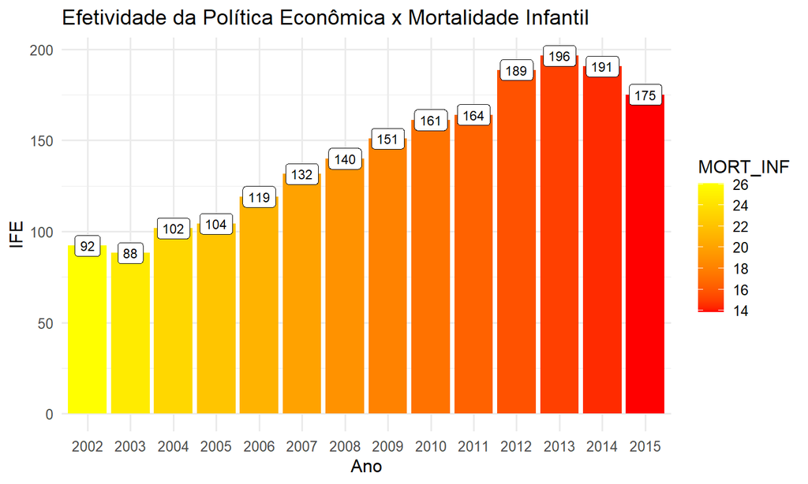

## Gráfico do IFE por ano e Gini

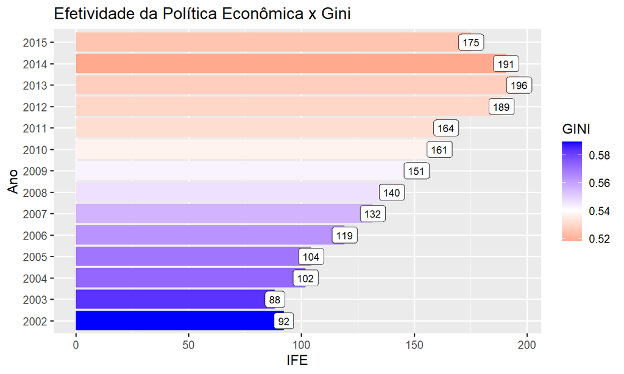